# Part I - PROSPER LOAN DATA

## Introduction

This project is divided into two major parts:

In the first part, we will conduct an exploratory data analysis on a dataset of your choosing. We will use Python data science and data visualization libraries to explore the dataset’s variables and understand the data’s structure, oddities, patterns and relationships. The analysis in this part is structured, going from simple univariate relationships up through multivariate relationships.

In the second part, We will take our main findings from our exploration and convey them to others through an explanatory analysis. To this end, We will create a slide deck that leverages polished, explanatory visualizations to communicate your results.

## Preliminary Wrangling

```python
# import all packages and set plots to be embedded inline
import numpy as np
import pandas as pd
import matplotlib.pyplot as plt
import seaborn as sb

%matplotlib inline
```

```python
# Read the data and view the data to visually assess it for analysis
data = pd.read_csv("C:/Users/tturyarugayo/Downloads/prosperLoanData.csv")
data.head()
```

|  | ListingKey | ListingNumber | ListingCreationDate | CreditGrade | Term | LoanStatus | ClosedDate | BorrowerAPR | BorrowerRate | LenderYield | ... | LP_ServiceFees | LP_CollectionFees | LP_GrossPrincipalLoss | LP_NetPrincipalLoss | LP_NonPrincipalRecoverypayments | PercentFunded | Recommendations | InvestmentFromFriendsCount | InvestmentFromFriendsAmount | Investors |
| --- | --- | --- | --- | --- | --- | --- | --- | --- | --- | --- | --- | --- | --- | --- | --- | --- | --- | --- | --- | --- | --- |
| 0 | 1021339766868145413AB3B | 193129 | 2007-08-26 19:09:29.263000000 | C | 36 | Completed | 2009-08-14 00:00:00 | 0.16516 | 0.1580 | 0.1380 | ... | -133.18 | 0.0 | 0.0 | 0.0 | 0.0 | 1.0 | 0 | 0 | 0.0 | 258 |
| 1 | 10273602499503308B223C1 | 1209647 | 2014-02-27 08:28:07.900000000 | NaN | 36 | Current | NaN | 0.12016 | 0.0920 | 0.0820 | ... | 0.00 | 0.0 | 0.0 | 0.0 | 0.0 | 1.0 | 0 | 0 | 0.0 | 1 |
| 2 | 0EE9337825851032864889A | 81716 | 2007-01-05 15:00:47.090000000 | HR | 36 | Completed | 2009-12-17 00:00:00 | 0.28269 | 0.2750 | 0.2400 | ... | -24.20 | 0.0 | 0.0 | 0.0 | 0.0 | 1.0 | 0 | 0 | 0.0 | 41 |
| 3 | 0EF5356002482715299901A | 658116 | 2012-10-22 11:02:35.010000000 | NaN | 36 | Current | NaN | 0.12528 | 0.0974 | 0.0874 | ... | -108.01 | 0.0 | 0.0 | 0.0 | 0.0 | 1.0 | 0 | 0 | 0.0 | 158 |
| 4 | 0F023589499656230C5E3E2 | 909464 | 2013-09-14 18:38:39.097000000 | NaN | 36 | Current | NaN | 0.24614 | 0.2085 | 0.1985 | ... | -60.27 | 0.0 | 0.0 | 0.0 | 0.0 | 1.0 | 0 | 0 | 0.0 | 20 |

5 rows × 81 columns

```python
# overview of data and its composition
print(data.shape)
print(data.info())
```

```
(113937, 81)
<class 'pandas.core.frame.DataFrame'>
RangeIndex: 113937 entries, 0 to 113936
Data columns (total 81 columns):
 #   Column                               Non-Null Count   Dtype
---  ------                               --------------   -----
 0   ListingKey                           113937 non-null  object
 1   ListingNumber                        113937 non-null  int64
 2   ListingCreationDate                  113937 non-null  object
 3   CreditGrade                          28953 non-null   object
 4   Term                                 113937 non-null  int64
 5   LoanStatus                           113937 non-null  object
 6   ClosedDate                           55089 non-null   object
 7   BorrowerAPR                          113912 non-null  float64
 8   BorrowerRate                         113937 non-null  float64
```

[output cut: 75 more lines]

```python
# Attain descriptive parameters for each variable.
data.describe()
```

|  | ListingNumber | Term | BorrowerAPR | BorrowerRate | LenderYield | EstimatedEffectiveYield | EstimatedLoss | EstimatedReturn | ProsperRating (numeric) | ProsperScore | ... | LP_ServiceFees | LP_CollectionFees | LP_GrossPrincipalLoss | LP_NetPrincipalLoss | LP_NonPrincipalRecoverypayments | PercentFunded | Recommendations | InvestmentFromFriendsCount | InvestmentFromFriendsAmount | Investors |
| --- | --- | --- | --- | --- | --- | --- | --- | --- | --- | --- | --- | --- | --- | --- | --- | --- | --- | --- | --- | --- | --- |
| count | 1.139370e+05 | 113937.000000 | 113912.000000 | 113937.000000 | 113937.000000 | 84853.000000 | 84853.000000 | 84853.000000 | 84853.000000 | 84853.000000 | ... | 113937.000000 | 113937.000000 | 113937.000000 | 113937.000000 | 113937.000000 | 113937.000000 | 113937.000000 | 113937.000000 | 113937.000000 | 113937.000000 |
| mean | 6.278857e+05 | 40.830248 | 0.218828 | 0.192764 | 0.182701 | 0.168661 | 0.080306 | 0.096068 | 4.072243 | 5.950067 | ... | -54.725641 | -14.242698 | 700.446342 | 681.420499 | 25.142686 | 0.998584 | 0.048027 | 0.023460 | 16.550751 | 80.475228 |
| std | 3.280762e+05 | 10.436212 | 0.080364 | 0.074818 | 0.074516 | 0.068467 | 0.046764 | 0.030403 | 1.673227 | 2.376501 | ... | 60.675425 | 109.232758 | 2388.513831 | 2357.167068 | 275.657937 | 0.017919 | 0.332353 | 0.232412 | 294.545422 | 103.239020 |
| min | 4.000000e+00 | 12.000000 | 0.006530 | 0.000000 | -0.010000 | -0.182700 | 0.004900 | -0.182700 | 1.000000 | 1.000000 | ... | -664.870000 | -9274.750000 | -94.200000 | -954.550000 | 0.000000 | 0.700000 | 0.000000 | 0.000000 | 0.000000 | 1.000000 |
| 25% | 4.009190e+05 | 36.000000 | 0.156290 | 0.134000 | 0.124200 | 0.115670 | 0.042400 | 0.074080 | 3.000000 | 4.000000 | ... | -73.180000 | 0.000000 | 0.000000 | 0.000000 | 0.000000 | 1.000000 | 0.000000 | 0.000000 | 0.000000 | 2.000000 |
| 50% | 6.005540e+05 | 36.000000 | 0.209760 | 0.184000 | 0.173000 | 0.161500 | 0.072400 | 0.091700 | 4.000000 | 6.000000 | ... | -34.440000 | 0.000000 | 0.000000 | 0.000000 | 0.000000 | 1.000000 | 0.000000 | 0.000000 | 0.000000 | 44.000000 |
| 75% | 8.926340e+05 | 36.000000 | 0.283810 | 0.250000 | 0.240000 | 0.224300 | 0.112000 | 0.116600 | 5.000000 | 8.000000 | ... | -13.920000 | 0.000000 | 0.000000 | 0.000000 | 0.000000 | 1.000000 | 0.000000 | 0.000000 | 0.000000 | 115.000000 |
| max | 1.255725e+06 | 60.000000 | 0.512290 | 0.497500 | 0.492500 | 0.319900 | 0.366000 | 0.283700 | 7.000000 | 11.000000 | ... | 32.060000 | 0.000000 | 25000.000000 | 25000.000000 | 21117.900000 | 1.012500 | 39.000000 | 33.000000 | 25000.000000 | 1189.000000 |

8 rows × 61 columns

> Out of the 113937 rows and 81 columns, I am going to select only the columns that are related to our exploration of the loan. I will chose about 20 columns to investigate. These columns are related to the amount of loan, dates, rates and other charactrestics about the borrowers.

```python
# Columns needed for my visualisation
columns = ['ListingKey','Term', 'LoanStatus','BorrowerAPR', 'BorrowerRate','EstimatedReturn', 'ProsperScore', 'ListingCategory (numeric)',
           'Occupation', 'EmploymentStatus', 'EmploymentStatusDuration', 'IsBorrowerHomeowner', 'CreditScoreRangeLower',
           'CreditScoreRangeUpper','AvailableBankcardCredit', 'DebtToIncomeRatio', 'IncomeRange', 'StatedMonthlyIncome',
          'LoanOriginalAmount', 'MonthlyLoanPayment','Investors'
]
loans_data = data[columns]
loans_data.info()
# Create a copy for cleaning the data
loans = loans_data.copy()
```

```
<class 'pandas.core.frame.DataFrame'>
RangeIndex: 113937 entries, 0 to 113936
Data columns (total 21 columns):
 #   Column                     Non-Null Count   Dtype
---  ------                     --------------   -----
 0   ListingKey                 113937 non-null  object
 1   Term                       113937 non-null  int64
 2   LoanStatus                 113937 non-null  object
 3   BorrowerAPR                113912 non-null  float64
 4   BorrowerRate               113937 non-null  float64
 5   EstimatedReturn            84853 non-null   float64
 6   ProsperScore               84853 non-null   float64
 7   ListingCategory (numeric)  113937 non-null  int64
 8   Occupation                 110349 non-null  object
 9   EmploymentStatus           111682 non-null  object
 10  EmploymentStatusDuration   106312 non-null  float64
 11  IsBorrowerHomeowner        113937 non-null  bool
 12  CreditScoreRangeLower      113346 non-null  float64
 13  CreditScoreRangeUpper      113346 non-null  float64
 14  AvailableBankcardCredit    106393 non-null  float64
 15  DebtToIncomeRatio          105383 non-null  float64
 16  IncomeRange                113937 non-null  object
 17  StatedMonthlyIncome        113937 non-null  float64
 18  LoanOriginalAmount         113937 non-null  int64
 19  MonthlyLoanPayment         113937 non-null  float64
 20  Investors                  113937 non-null  int64
dtypes: bool(1), float64(11), int64(4), object(5)
memory usage: 17.5+ MB
```

```python
# Check for duplicates in the selected columns for the loans data.
loans.duplicated().sum()
```

```
0
```

```python
# Check for missing values
loans.isnull().sum()
```

```
ListingKey                       0
Term                             0
LoanStatus                       0
BorrowerAPR                     25
BorrowerRate                     0
EstimatedReturn              29084
ProsperScore                 29084
ListingCategory (numeric)        0
Occupation                    3588
EmploymentStatus              2255
EmploymentStatusDuration      7625
IsBorrowerHomeowner              0
CreditScoreRangeLower          591
CreditScoreRangeUpper          591
AvailableBankcardCredit       7544
DebtToIncomeRatio             8554
IncomeRange                      0
StatedMonthlyIncome              0
LoanOriginalAmount               0
MonthlyLoanPayment               0
Investors                        0
dtype: int64
```

```python
# obtain the values in the employment status and occupation columns to ensure that the entries captured as NAN are transfered to not available
print(loans.EmploymentStatus.value_counts())
print(loans.Occupation.value_counts())
```

```
Employed         67322
Full-time        26355
Self-employed     6134
Not available     5347
Other             3806
Part-time         1088
Not employed       835
Retired            795
Name: EmploymentStatus, dtype: int64
Other                          28617
Professional                   13628
Computer Programmer             4478
Executive                       4311
Teacher                         3759
                               ...
Dentist                           68
Student - College Freshman        41
Student - Community College       28
Judge                             22
Student - Technical School        16
Name: Occupation, Length: 67, dtype: int64
```

```python
#Lets replace Nan values with 'Not available'. since occupation doesn't account for entries to be captured as Not available therefore we shall the missing values for occupation
loans.EmploymentStatus.fillna('Not available', inplace=True)
```

```python
# Confirm that the changes have been effected.
loans.EmploymentStatus.value_counts()
```

```
Employed         67322
Full-time        26355
Not available     7602
Self-employed     6134
Other             3806
Part-time         1088
Not employed       835
Retired            795
Name: EmploymentStatus, dtype: int64
```

```python
# drop the remaining missing values
loans = loans.dropna()
print(loans.info())
print(loans.isnull().sum())
```

```
<class 'pandas.core.frame.DataFrame'>
Int64Index: 76216 entries, 1 to 113936
Data columns (total 21 columns):
 #   Column                     Non-Null Count  Dtype
---  ------                     --------------  -----
 0   ListingKey                 76216 non-null  object
 1   Term                       76216 non-null  int64
 2   LoanStatus                 76216 non-null  object
 3   BorrowerAPR                76216 non-null  float64
 4   BorrowerRate               76216 non-null  float64
 5   EstimatedReturn            76216 non-null  float64
 6   ProsperScore               76216 non-null  float64
 7   ListingCategory (numeric)  76216 non-null  int64
 8   Occupation                 76216 non-null  object
 9   EmploymentStatus           76216 non-null  object
 10  EmploymentStatusDuration   76216 non-null  float64
 11  IsBorrowerHomeowner        76216 non-null  bool
 12  CreditScoreRangeLower      76216 non-null  float64
 13  CreditScoreRangeUpper      76216 non-null  float64
 14  AvailableBankcardCredit    76216 non-null  float64
 15  DebtToIncomeRatio          76216 non-null  float64
 16  IncomeRange                76216 non-null  object
 17  StatedMonthlyIncome        76216 non-null  float64
 18  LoanOriginalAmount         76216 non-null  int64
 19  MonthlyLoanPayment         76216 non-null  float64
 20  Investors                  76216 non-null  int64
dtypes: bool(1), float64(11), int64(4), object(5)
memory usage: 12.3+ MB
None
ListingKey                   0
Term                         0
LoanStatus                   0
BorrowerAPR                  0
BorrowerRate                 0
EstimatedReturn              0
ProsperScore                 0
ListingCategory (numeric)    0
Occupation                   0
EmploymentStatus             0
EmploymentStatusDuration     0
IsBorrowerHomeowner          0
CreditScoreRangeLower        0
CreditScoreRangeUpper        0
AvailableBankcardCredit      0
DebtToIncomeRatio            0
IncomeRange                  0
StatedMonthlyIncome          0
LoanOriginalAmount           0
MonthlyLoanPayment           0
Investors                    0
dtype: int64
```

```python
# Convert IncomeRange to ordinal categorical
ordinal_category = {'IncomeRange':['$0','$1-24,999','$25,000-49,999','$50,000-74,999','$75,000-99,999','$100,000+']}
for var in ordinal_category:
    order = pd.api.types.CategoricalDtype(ordered = True, categories = ordinal_category[var])
    loans[var] = loans[var].astype(order)
```

```python
# Confirm that the changes have taken effect
loans.IncomeRange.value_counts()
```

```
$50,000-74,999    23692
$25,000-49,999    21421
$100,000+         13977
$75,000-99,999    13547
$1-24,999          3578
$0                    0
Name: IncomeRange, dtype: int64
```

```python
# Obtain the different values under the listing category
loans['ListingCategory (numeric)'].value_counts()
```

```
1     48604
7      8280
2      6328
3      3644
6      2032
13     1767
15     1382
14      795
18      783
20      729
19      712
16      289
5       201
11      201
8       191
9        83
10       82
17       49
12       45
0        19
Name: ListingCategory (numeric), dtype: int64
```

```python
# rename the Listing Category Column
loans.rename(columns={'ListingCategory (numeric)': 'ListingCategory'},inplace=True)
# Create a categorical variable for the list category column according to entries.
list_category={0:'Not Available',1:'Debt Consolidation',2:'Home Improvement',3:'Business',4:'Personal Loan',5:
               'Student Use',6:'Auto',7:'Other',8:'Baby&Adoption',9:'Boat',10:'Cosmetic Procedure',11:
               'Engagement Ring',12:'Green Loans',13:'Household Expenses',14:'Large Purchases',15:
               'Medical/Dental',16:'Motorcycle',17:'RV',18:'Taxes',19:'Vacation',20:'Wedding Loans'}
def listing (x,y = list_category):
    return y[x]
loans['ListingCategory'] =loans['ListingCategory'].apply(listing)
```

```python
# check if the entries in the column have changed successfully
loans.ListingCategory.value_counts()
```

```
Debt Consolidation    48604
Other                  8280
Home Improvement       6328
Business               3644
Auto                   2032
Household Expenses     1767
Medical/Dental         1382
Large Purchases         795
Taxes                   783
Wedding Loans           729
Vacation                712
Motorcycle              289
Student Use             201
Engagement Ring         201
Baby&Adoption           191
Boat                     83
Cosmetic Procedure       82
RV                       49
Green Loans              45
Not Available            19
Name: ListingCategory, dtype: int64
```

```python
loans['LoanStatus']= pd.Categorical(loans['LoanStatus'],categories =['Completed','Current',
                                                                     'FinalPaymentInProgress', "Past Due (1-15 days)",
                                                                     'Past Due (31-60 days)', 'Pas tDue (31-60 days)',
                                                                     'Past Due (61-90 days)', 'Past Due (91-120 days)',
                                                                     'Chargedoff', 'Defaulted'],ordered=True)
# Change data types of categorical variables to category
loans['Occupation'] = loans['Occupation'].astype('category')
loans['LoanStatus'] = loans['LoanStatus'].astype('category')
loans['ListingCategory'] = loans['ListingCategory'].astype('category')
loans['EmploymentStatus'] = loans['EmploymentStatus'].astype('category')
loans['ProsperScore'] = loans['ProsperScore'].astype('category')
loans['IncomeRange'] = loans['IncomeRange'].astype('category')
```

```python
loans.shape
```

```
(76216, 21)
```

### What is/are the main feature(s) of interest in your dataset?

> The main feature of interest in the dataset are
> - What affects the borrower's APR?
> - What affects the loan status?
> - What affects the Loan Original amount?</br> Therefore, the features that I'm most interested in are those that I deem best for predicting the borrower's APR and loan status.

### What features in the dataset do you think will help support your investigation into your feature(s) of interest?

> Though there are many features to explore, I suspect the following borrower features will have the largest effect on the performance of the loan:
- IncomeRange - The income range of the borrower at the time the listing was created.</br>
- Occupation - The Occupation selected by the Borrower at the time they created the listing.</br>
- EmploymentStatus - The employment status of the borrower at the time they posted the listing.</br>
- Term - The length of the loan expressed in months.</br>
- DebtToIncomeRatio - The debt to income ratio of the borrower at the time the credit profile was pulled. This value is Null if the debt to income ratio is not available. This value is capped at 10.01 (any debt to income ratio larger than 1000% will be returned as 1001%).

## Univariate Exploration

> In this section, investigate distributions of individual variables. If you see unusual points or outliers, take a deeper look to clean things up and prepare yourself to look at relationships between variables.

#### Question1: What is the distribution of the loan status and which one is more common than the rest?

```python
# First, we get the value_counts
loans.LoanStatus.value_counts()
```

```
Current                   51170
Completed                 17687
Chargedoff                 4444
Defaulted                   885
Past Due (1-15 days)        714
Past Due (31-60 days)       322
Past Due (91-120 days)      277
Past Due (61-90 days)       275
FinalPaymentInProgress      187
Pas tDue (31-60 days)         0
Name: LoanStatus, dtype: int64
```

#### Visualization

```python
# Setting colors
base_color = sb.color_palette()[0]
base_color2 = sb.color_palette()[2]
base_color3 = sb.color_palette()[3]
base_color4 = sb.color_palette()[4]
base_color5 = sb.color_palette()[5]
base_color6 = sb.color_palette()[6]
base_color7 = sb.color_palette()[7]
base_color8 = sb.color_palette()[8]
```

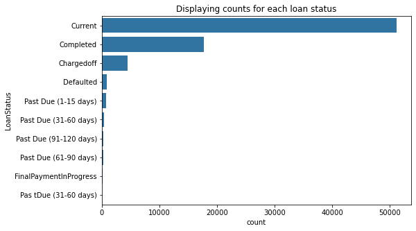

```python
# Produce a countplot visualization
plt.figure(figsize=(8,5))
data_order = loans.LoanStatus.value_counts().index
sb.countplot(y='LoanStatus',data = loans,color=base_color, order = data_order)
plt.title('Displaying counts for each loan status');
```

#### Question 2: Which Term ( Length of the loan) has the highest number of loans?

```python
# Obtain the value_counts
loans.Term.value_counts()
```

```
36    51919
60    22883
12     1414
Name: Term, dtype: int64
```

#### Visualization

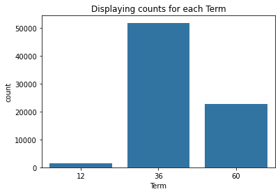

```python
#produce a barchart to display the number of loans per
sb.countplot(x='Term',data = loans,color=base_color)
plt.title('Displaying counts for each Term');
```

#### Observation

The length of 36 months has the most number of loans followed by the length of 60 months and lastly 12 months.

#### Question 3: What is the distribution of the borrower APR?

```python
#obatin descriptives for the borrowerAPR column
loans.BorrowerAPR.describe()
```

```
count    76216.000000
mean         0.223901
std          0.079372
min          0.045830
25%          0.161570
50%          0.215660
75%          0.287800
max          0.423950
Name: BorrowerAPR, dtype: float64
```

#### Visualization

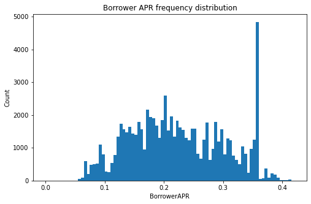

```python
# Produce a barchart to visualise the distribution of borrowerAPR
plt.figure(figsize=(8,5))
b = np.arange(0,loans['BorrowerAPR'].value_counts().index.max(),0.005)
plt.hist(data = loans, x = 'BorrowerAPR', bins = b);
plt.title('Borrower APR frequency distribution');
plt.xlabel('BorrowerAPR');
plt.ylabel('Count');
```

```python
#Attain the descriptives of the estimated returns
loans.ProsperScore.value_counts()
```

```
8.0     11432
6.0     11156
4.0     10826
7.0      9816
5.0      8643
9.0      6588
3.0      6374
2.0      4674
10.0     4600
11.0     1392
1.0       715
Name: ProsperScore, dtype: int64
```

#### Visualization

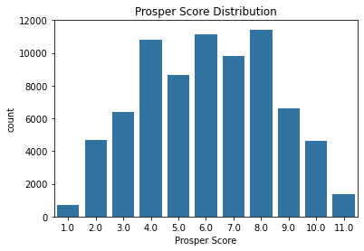

```python
# produce a countplot to visualize the count of the prosperscore
sb.countplot(data= loans, x= 'ProsperScore', color=base_color)
plt.title('Prosper Score Distribution')
plt.xlabel('Prosper Score');
```

#### Observation

The prosper Score of 8 has the highest count appearing with over 11,000 counts preceded by 6 with a count slight less than that of 8 and the prosper score of 1 has the least count with less than 1,000 occurences.

#### Question 5: What is the count of the respective listing category?

```python
# obtain the value counts for the listing category
loans.ListingCategory.value_counts()
```

```
Debt Consolidation    48604
Other                  8280
Home Improvement       6328
Business               3644
Auto                   2032
Household Expenses     1767
Medical/Dental         1382
Large Purchases         795
Taxes                   783
Wedding Loans           729
Vacation                712
Motorcycle              289
Engagement Ring         201
Student Use             201
Baby&Adoption           191
Boat                     83
Cosmetic Procedure       82
RV                       49
Green Loans              45
Not Available            19
Name: ListingCategory, dtype: int64
```

#### Visualization

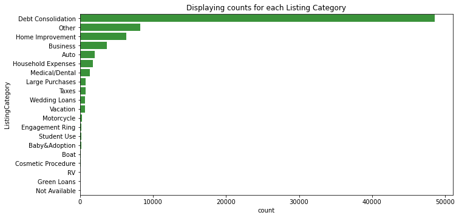

```python
# Produce a countplot for the respective listing categories
plt.figure(figsize=(11,5.5))
list_order = loans.ListingCategory.value_counts().index
sb.countplot(y='ListingCategory',data = loans,color=base_color2, order = list_order)
plt.title('Displaying counts for each Listing Category');
```

#### Question 6: What is the count of each occupation type?

```python
# Obtain value counts of each occupation
loans.Occupation.value_counts()
```

```
Other                          18501
Professional                    9916
Executive                       3206
Computer Programmer             3038
Teacher                         2777
                               ...
Student - College Junior          19
Student - College Freshman        12
Student - College Sophomore        9
Student - Community College        5
Student - Technical School         1
Name: Occupation, Length: 67, dtype: int64
```

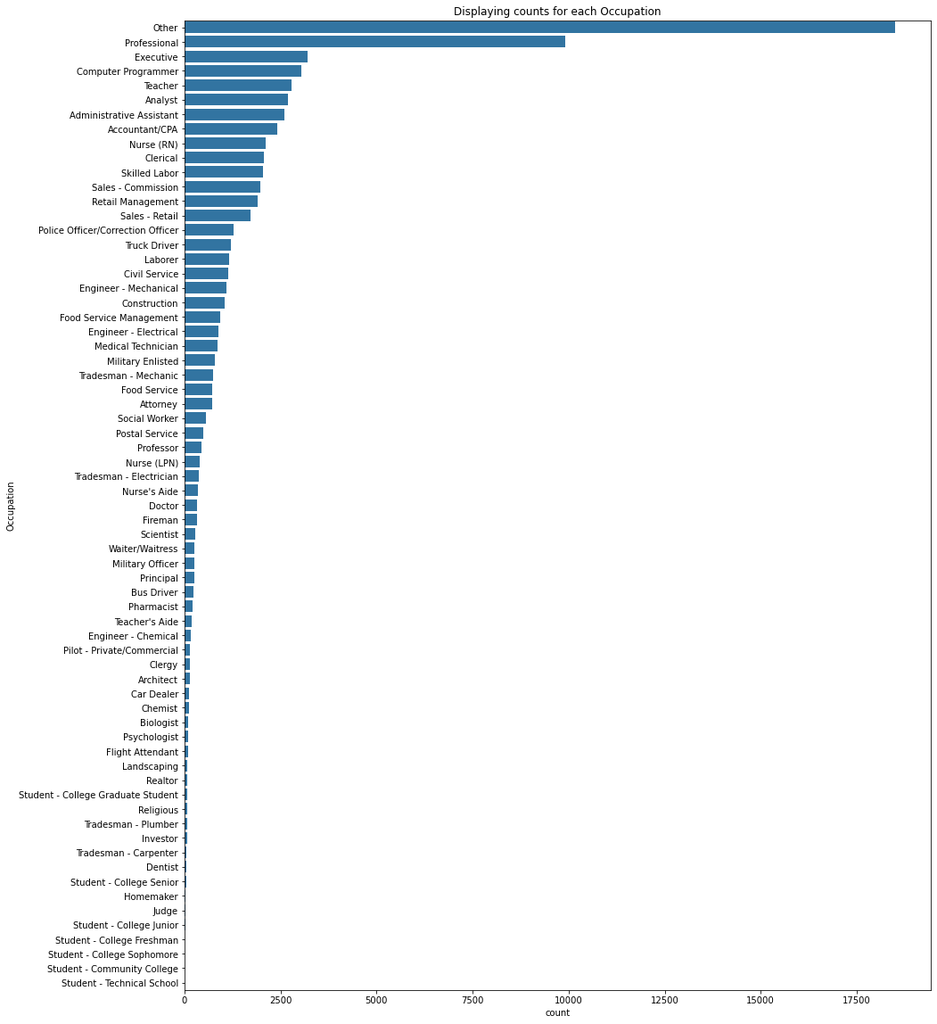

```python
# Plot a count plot of each occupation
plt.figure(figsize=(15,20))
occupation_order = loans.Occupation.value_counts().index
sb.countplot(y= 'Occupation',data = loans,color=base_color, order = occupation_order)
plt.title('Displaying counts for each Occupation');
```

#### Observation

Over 17,500 of the respondents do other occupation types other than the ones in the dropdown menu followed by the professional option.

#### Question 7: What is the count of each employment status?

```python
# Attain the value counts for each employment status
loans.EmploymentStatus.value_counts()
```

```
Employed         65883
Full-time         7577
Other             2194
Retired            320
Part-time          199
Self-employed       42
Not employed         1
Name: EmploymentStatus, dtype: int64
```

#### Visualization

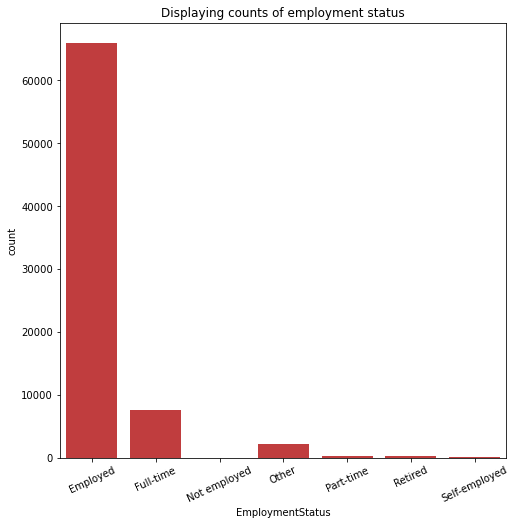

```python
# Plotting countplot.
plt.figure(figsize=(8,8))
sb.countplot(x='EmploymentStatus',data=loans,color=base_color3)
plt.xticks(rotation=25)
plt.title('Displaying counts of employment status');
```

#### Observation

Majority of the people who applied for the loans were employed and significantly only one person applied for while being not employed

#### Question 8: What are the descriptives of the employment status duration?

```python
# Attain the descriptives of the employment status duration
loans.EmploymentStatusDuration.describe()
```

```
count    76216.000000
mean       104.578028
std         95.836443
min          0.000000
25%         32.000000
50%         76.000000
75%        150.000000
max        755.000000
Name: EmploymentStatusDuration, dtype: float64
```

#### Visualization

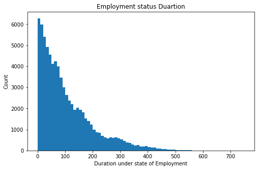

```python
# Produce a barchart to visualise the distribution of borrowerAPR
plt.figure(figsize=(8,5))
b = np.arange(0,loans['EmploymentStatusDuration'].value_counts().index.max(),10)
plt.hist(data = loans, x = 'EmploymentStatusDuration', bins = b);
plt.title('Employment status Duartion');
plt.xlabel('Duration under state of Employment');
plt.ylabel('Count');
```

#### Observation

The Duration spent under a state of employment is skewed to the right and majority of people have spent between 0 and 100 months in the state of employment.

#### Question 9: What proportion of people own homes?

```python
# Attain the value counts of the home owners
home= loans.IsBorrowerHomeowner.value_counts()
home
```

```
True     41454
False    34762
Name: IsBorrowerHomeowner, dtype: int64
```

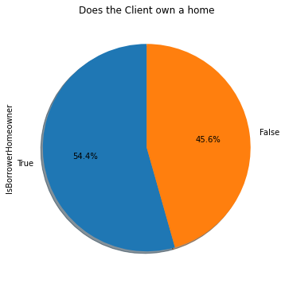

```python
# Plot a pie chart to view a proportion of clients who own a home
explode = (0, 0.1, 0, 0)
home.plot.pie(figsize=(7, 6),autopct='%1.1f%%',shadow=True, startangle=90,counterclock=True)
plt.title('Does the Client own a home')
```

#### Observation

54.4% of the clients own a home and 45.6% of the clients don't own a home.

#### Question 10: What balance do the clients have on their banks while apply for loans?

```python
# attain descriptives of the bank card credit available
loans.AvailableBankcardCredit.describe()
```

```
count     76216.000000
mean      11169.208618
std       18224.239106
min           0.000000
25%        1115.000000
50%        4497.000000
75%       13587.250000
max      498374.000000
Name: AvailableBankcardCredit, dtype: float64
```

#### Visualization

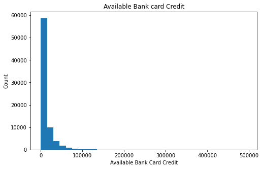

```python
# Produce a barchart to visualise the distribution of borrowerAPR
plt.figure(figsize=(8,5))
b = np.arange(0,loans['AvailableBankcardCredit'].value_counts().index.max(),15000)
plt.hist(data = loans, x = 'AvailableBankcardCredit', bins = b);
plt.title('Available Bank card Credit');
plt.xlabel('Available Bank Card Credit');
plt.ylabel('Count');
```

#### Observation

The graph of available bank credit is skewed to the right with majority of the clients having between 0 and 15,000 on the bank card.

#### Question 11: What is the distribution of Debt to Income Ratio?

```python
# Attaining the descriptive statsitics
loans.DebtToIncomeRatio.describe()
```

```
count    76216.000000
mean         0.258032
std          0.320587
min          0.000000
25%          0.150000
50%          0.220000
75%          0.320000
max         10.010000
Name: DebtToIncomeRatio, dtype: float64
```

#### Visualization

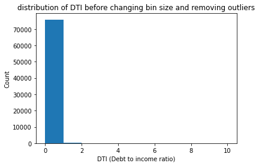

```python
# Plotting histogram
plt.hist(data= loans,x='DebtToIncomeRatio')
plt.title('distribution of DTI before changing bin size and removing outliers')
plt.xlabel('DTI (Debt to income ratio)');
plt.ylabel('Count')
```

#### Observation

Majority of the data lies between 0 and 1 and basing on the mean of 0.258 yet the maximum is 10.1 implying there are outliers in this column that have to be dropped.

#### Removing Outliers

```python
outliers = loans.DebtToIncomeRatio>1
loans_outliers = loans.loc[outliers,:]
print(loans_outliers)
# Drop these outliers
loans = loans.loc[loans.DebtToIncomeRatio<1]
print(loans.DebtToIncomeRatio.describe())
```

[output not shown]

[output cut: 33 more lines]

```
113367                2000               86.38          1
113387                1500               67.85         17
113486                2500              108.87          1
113718                4000              172.76          1

[322 rows x 21 columns]
count    75887.000000
mean         0.244480
std          0.129475
min          0.000000
25%          0.150000
50%          0.220000
75%          0.320000
max          0.990000
Name: DebtToIncomeRatio, dtype: float64
```

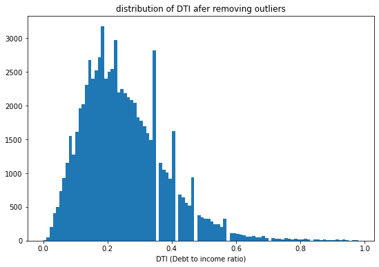

```python
# Plotting histogram after remvoing outliers
plt.figure(figsize=(9,6))
b = np.arange(0,loans['DebtToIncomeRatio'].value_counts().index.max(),0.01)
plt.hist(data= loans,x='DebtToIncomeRatio', bins = b)
plt.title('distribution of DTI afer removing outliers')
plt.xlabel('DTI (Debt to income ratio)');
```

#### Observation

After removing the outliers, the distribution is still skewed to the rightand most of the entries are below 0.4

#### Question 12: What is the count of the different income ranges?

```python
# Attain value counts of the different income ranges
loans.IncomeRange.value_counts()
```

```
$50,000-74,999    23687
$25,000-49,999    21382
$100,000+         13972
$75,000-99,999    13545
$1-24,999          3300
$0                    0
Name: IncomeRange, dtype: int64
```

#### Visualization

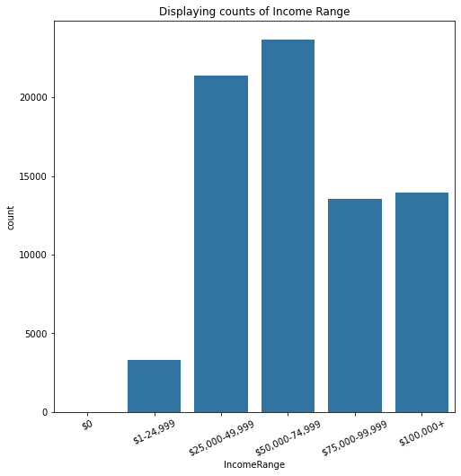

```python
# Plotting countplot.
plt.figure(figsize=(8,8))
sb.countplot(x='IncomeRange',data=loans,color=base_color)
plt.xticks(rotation=25)
plt.title('Displaying counts of Income Range');
```

#### Observation

The income range $50,000- 74,999$ has the highest number of counts and $1 - 24,999$ has the least number of counts.

#### Question 13: What is the distribution of the Loan Original Amount?

```python
# Attain descriptives for the stated monthly income
loans.LoanOriginalAmount.describe()
```

```
count    75887.000000
mean      9311.390765
std       6417.021988
min       1000.000000
25%       4000.000000
50%       8000.000000
75%      15000.000000
max      35000.000000
Name: LoanOriginalAmount, dtype: float64
```

#### Visualization

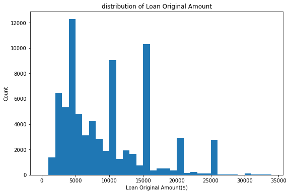

```python
##### Plotting histogram
plt.figure(figsize=(9,6))
b = np.arange(0,loans['LoanOriginalAmount'].value_counts().index.max(),1000)
plt.hist(data= loans,x='LoanOriginalAmount', bins=b)
plt.title('distribution of Loan Original Amount')
plt.xlabel('Loan Original Amount($)');
plt.ylabel('Count')
```

#### There is overplotting in the above graph therefore I decide to use logs.

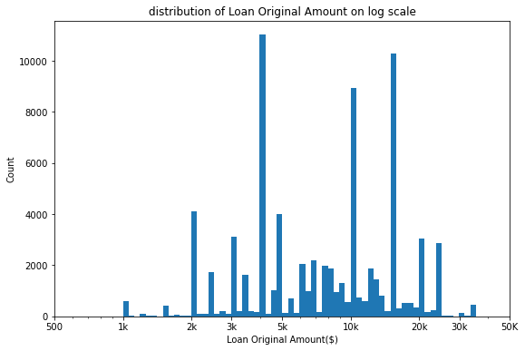

```python
# Putting Loan Original Amount in a log-scale
plt.figure(figsize=(9,6))
log_binsize = 0.025
b = 10 ** np.arange(3, np.log10(loans['LoanOriginalAmount'].max())+log_binsize, log_binsize)
plt.hist(data= loans,x='LoanOriginalAmount', bins=b)
plt.title('distribution of Loan Original Amount on log scale')
plt.xscale('log')
plt.xticks([500, 1e3, 2e3,3e3, 5e3, 1e4, 2e4, 3e4, 5e4], ['500', '1k', '2k', '3k', '5k', '10k', '20k', '30k', '50K'])
plt.xlabel('Loan Original Amount($)')
plt.ylabel('Count')
```

#### Observation

The highest loan original amount is between 3,000 and 5,000.

#### Question 14: What is the distribution the Investors?

```python
# Attain descriptives for the Investors
loans.Investors.describe()
```

```
count    75887.000000
mean        70.080304
std         97.933488
min          1.000000
25%          1.000000
50%         32.000000
75%        100.000000
max       1189.000000
Name: Investors, dtype: float64
```

#### Visualization

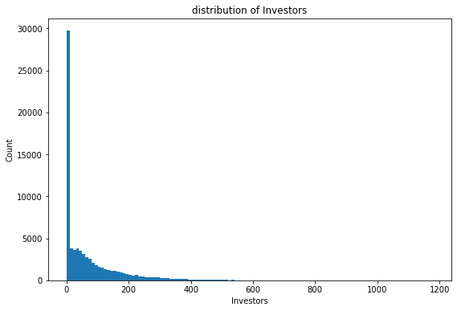

```python
##### Plotting histogram
plt.figure(figsize=(9,6))
b = np.arange(0,loans['Investors'].value_counts().index.max(),10)
plt.hist(data= loans,x='Investors', bins=b)
plt.title('distribution of Investors')
plt.xlabel('Investors');
plt.ylabel('Count')
```

#### The distribution is skewed to the right and there is overplotting therefore lets use log

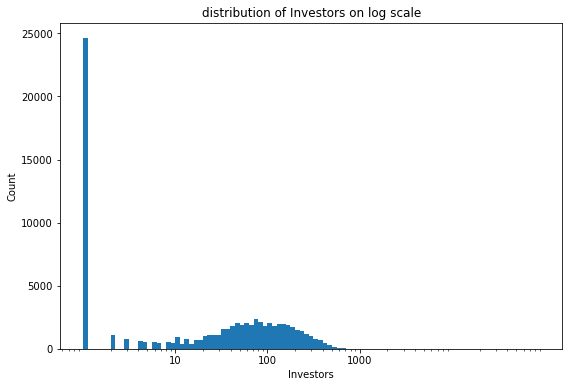

```python
# Plotting investors on log scale
log_binsize = 0.05
plt.figure(figsize=(9,6))
b = 10 ** np.arange(0, 5, log_binsize)
plt.hist(data= loans,x='Investors', bins=b)
plt.xscale('log')
plt.xticks([1e1, 1e2, 1e3], ['10', '100', '1000'])
plt.title('distribution of Investors on log scale')
plt.xlabel('Investors');
plt.ylabel('Count')
```

### Discuss the distribution(s) of your variable(s) of interest. Were there any unusual points? Did you need to perform any transformations?

> In debt to income variable, their were some points which were greater than 1. So, I considered them as outliers because when I did some research about minimum and maximum DTI, I found that maximum DTI can reach upto 50% or 0.5. So, it is very unlikely that DTI would be greater than 1. Loan Original Amount distribution is right skewed and I performed log transformation on it to interpret the visualization. I also did the log transformation to the investors varible since it was highly skewed to the right.

### Of the features you investigated, were there any unusual distributions? Did you perform any operations on the data to tidy, adjust, or change the form of the data? If so, why did you do this?

> I did some transformation on Debt to income ratio variable, Loan original amount variable, and investors variable. These transformations include:
> 1. Changing X-ticks to view more exact point of interest.
> 2. Changing bins size to reduce noise in the graph and view data more precisely.
> 3. Using log xscale to make interpretations from the graph easy.

## Bivariate Exploration

> To perform a bivariate exploration, we first study the relationship between the numberic variables.

#### Question 15: What is the relationship between the numeric variables?

```python
#Obtain the numeric variables
loans.info()
```

```
<class 'pandas.core.frame.DataFrame'>
Int64Index: 75887 entries, 1 to 113936
Data columns (total 21 columns):
 #   Column                    Non-Null Count  Dtype
---  ------                    --------------  -----
 0   ListingKey                75887 non-null  object
 1   Term                      75887 non-null  int64
 2   LoanStatus                75635 non-null  category
 3   BorrowerAPR               75887 non-null  float64
 4   BorrowerRate              75887 non-null  float64
 5   EstimatedReturn           75887 non-null  float64
 6   ProsperScore              75887 non-null  category
 7   ListingCategory           75887 non-null  category
 8   Occupation                75887 non-null  category
 9   EmploymentStatus          75887 non-null  category
 10  EmploymentStatusDuration  75887 non-null  float64
 11  IsBorrowerHomeowner       75887 non-null  bool
 12  CreditScoreRangeLower     75887 non-null  float64
 13  CreditScoreRangeUpper     75887 non-null  float64
 14  AvailableBankcardCredit   75887 non-null  float64
 15  DebtToIncomeRatio         75887 non-null  float64
 16  IncomeRange               75886 non-null  category
 17  StatedMonthlyIncome       75887 non-null  float64
 18  LoanOriginalAmount        75887 non-null  int64
 19  MonthlyLoanPayment        75887 non-null  float64
 20  Investors                 75887 non-null  int64
dtypes: bool(1), category(6), float64(10), int64(3), object(1)
memory usage: 9.2+ MB
```

```python
#select the numeric variables
numeric= ['Term', 'BorrowerAPR','BorrowerRate', 'EmploymentStatusDuration', 'AvailableBankcardCredit',
          'DebtToIncomeRatio', 'StatedMonthlyIncome', 'LoanOriginalAmount', 'MonthlyLoanPayment','Investors']
```

#### Visualization

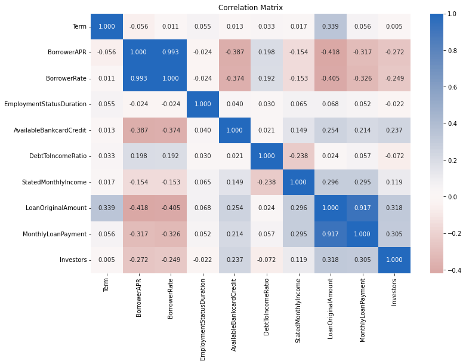

```python
# Correlation matrix for the numeric variables
plt.figure(figsize = [12, 8])
sb.heatmap(loans[numeric].corr(), annot = True, fmt = '.3f',cmap = 'vlag_r', center = 0)
plt.title('Correlation Matrix')
plt.show()
```

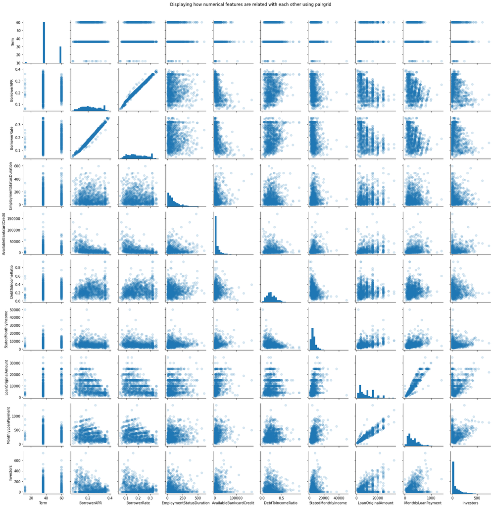

```python
# plot matrix: sample 1000 loans so that plots are clearer.
loans_samp = loans.sample(1000)
g = sb.PairGrid(data = loans_samp, vars = numeric,height=2)
g = g.map_diag(plt.hist, bins = 20)
g.map_offdiag(plt.scatter,alpha=1/6)
g.fig.suptitle('Displaying how numerical features are related with each other using pairgrid',y=1.02);
```

#### Observation

##### Basing on the heatmap, there is a strong positive correlation between:

- BorrowerRate and BorrowerAPR
- Loan Original Amount and Monthly Loan payment ##### There is negative correlation between:
- Loan Original Amount and BorrowerAPR
- Loan Original Amount and Borrower Rate
- Borrower APR and Available Bank Card Credit Balance
- Borrower Rate and Available Bank Card Credit Balance
- Borrower APR and Monthly loan Payment
- Borrower Rate and Monthly loan payment

#### Question 16: What is the Relationship between Loan Original Amount and Employment Status

#### Visualization

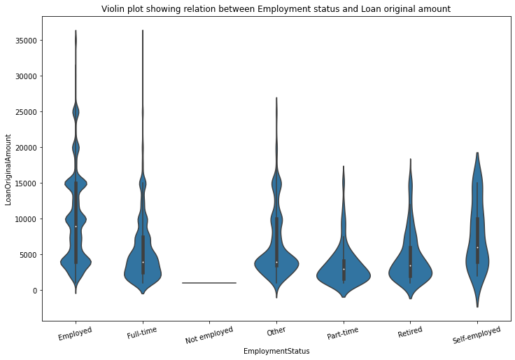

```python
# Plot a violin plot ot help visualise the loan original amount with employment status
plt.figure(figsize = [12, 8])
sb.violinplot(data=loans, x='EmploymentStatus', y='LoanOriginalAmount', color=base_color, innner=None)
plt.xticks(rotation=15)
plt.title('Violin plot showing relation between Employment status and Loan original amount');
```

#### Question 17: What is the relationship between Loan Original Amount and Loan status

#### Visualization

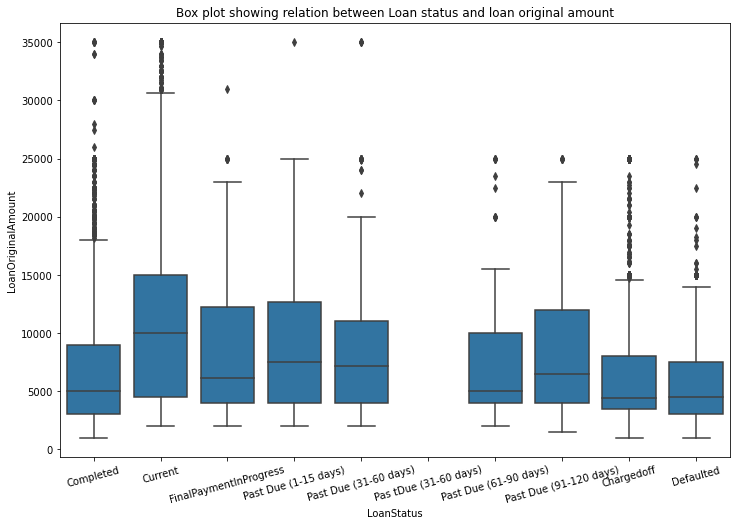

```python
# Plot a boxplot for the loan original amount and the loan status
plt.figure(figsize = [12, 8])
sb.boxplot(data=loans, x='LoanStatus', y='LoanOriginalAmount' ,color=base_color)
plt.xticks(rotation=15)
plt.title('Box plot showing relation between Loan status and loan original amount');
```

#### Observation

The clients with current and ongoing loans have the highest average which is greater than 10,000 and the clients who defaulted recieved a loan amount on average of less than 5,000.

#### Question 18: What is the relationship between Employment status and Borrower APR

#### Visualization

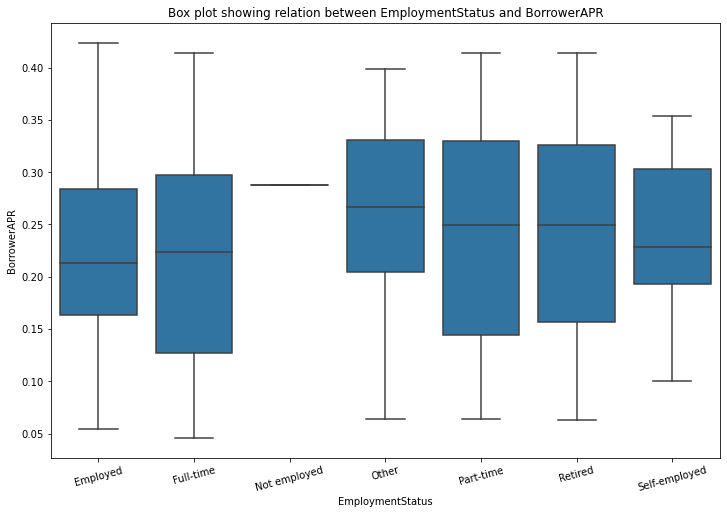

```python
# Plot a boxplot for the loan original amount and the loan status
plt.figure(figsize = [12, 8])
sb.boxplot(data=loans, x='EmploymentStatus', y='BorrowerAPR', color=base_color)
plt.xticks(rotation=15)
plt.title('Box plot showing relation between EmploymentStatus and BorrowerAPR');
```

#### Observation

The clients who are employeed have a better borrowerAPR than the rest of the clients.

#### Question 19: What is the relationship between loan original amount and prosper score

#### Visualization

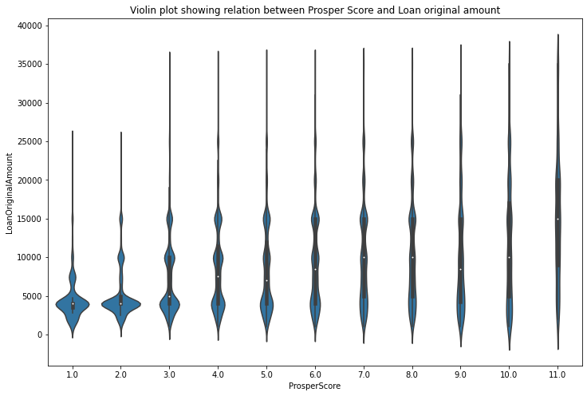

```python
# Plot a violin plot ot help visualise the loan original amount with prosper score
plt.figure(figsize = [12, 8])
sb.violinplot(data=loans, x='ProsperScore', y='LoanOriginalAmount', color=base_color, innner=None)
plt.title('Violin plot showing relation between Prosper Score and Loan original amount');
```

#### Observation

Clients witha prosper score of 11 recieved the highest loan original amount and clients with teh least prosper score recieved the least loan original amount.

#### Question 20: What the relationship between the Loan Status and IncomeRange

```python
# First select the categorical variables
categ = ['LoanStatus','ProsperScore', 'ListingCategory','Occupation','EmploymentStatus','IncomeRange']
```

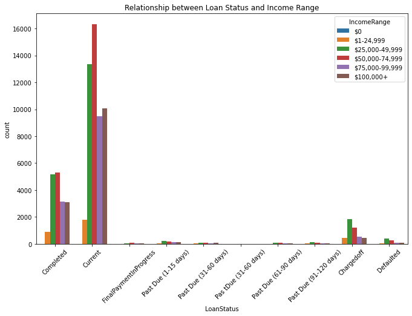

```python
plt.figure(figsize = [11, 7])
ax= sb.countplot(data = loans, x = 'LoanStatus', hue = 'IncomeRange', palette = 'tab10')
plt.xticks(rotation=45)
sb.move_legend(ax, "upper right")
plt.title('Relationship between Loan Status and Income Range')
```

#### Observation

The current loan status has the highest count of clients with the range of 50,000 - 74,999 being the most common.

#### Question 21: What is the relationship between the incomeRange and Employment status

#### Visualization

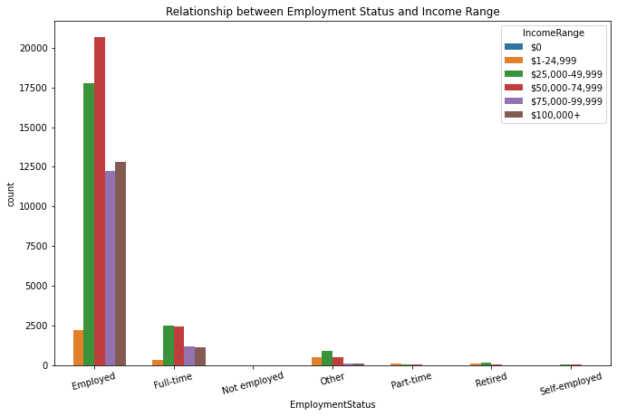

```python
# Plot a countplot to display the relationship between employment status and income range
plt.figure(figsize = [11, 7])
sb.countplot(data = loans, x = 'EmploymentStatus', hue = 'IncomeRange', palette = 'tab10')
plt.xticks(rotation=15)
plt.title('Relationship between Employment Status and Income Range')
```

#### Observation

The employed class has the highest count with the income range of 50,000 - 74,999 having the highest number of clients.

### Talk about some of the relationships you observed in this part of the investigation. How did the feature(s) of interest vary with other features in the dataset?

> - The BorrowerAPR and Monthly Loan payment have a negative correlation implying that an increase in the monthly Loan payment it leads to a decrease in the Borrower APR thus becoming a better client.
> - The BorrowerAPR and Available Bank Card Credit Balance have a negative correlation implying that an increase in the Available Bank Card Credit Balance leads to a decrease in the Borrower APR thus becoming a better client.
> - The loan Original Amount is dependant on th employment status and the employed are offered a higher loan original amount than the rest.

### Did you observe any interesting relationships between the other features (not the main feature(s) of interest)?

> - The Employed class have a higher count of income as compared to other classes.
> - The Loan orriginal Amount is dependant on the prosper score.

## Multivariate Exploration

> Create plots of three or more variables to investigate your data even further. Make sure that your investigations are justified, and follow from your work in the previous sections.

#### Question 22: What is the relationship between loan status, employment status and BorrowerAPR

#### Visualization

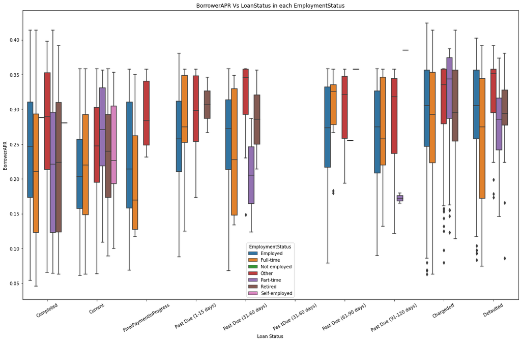

```python
# LoanStatus Vs BorrowerAPR in each EmploymentStatus
plt.figure(figsize=[20,12])
sb.boxplot(x="LoanStatus", y="BorrowerAPR", hue="EmploymentStatus", data=loans, palette="tab10");
plt.title('BorrowerAPR Vs LoanStatus in each EmploymentStatus');
plt.xlabel('Loan Status');
plt.ylabel('BorrowerAPR');
plt.xticks(rotation = 30);
```

#### Question 23: what is the effect of Term on the relationship of APR and loan amount

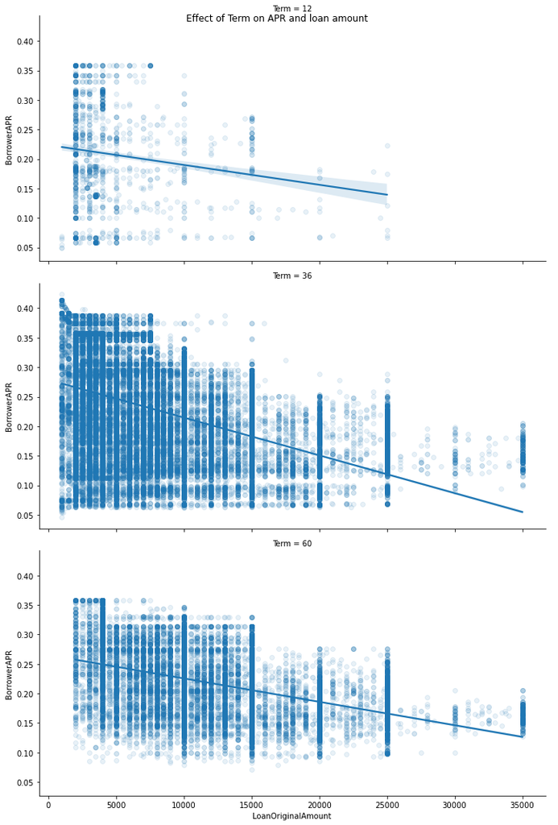

```python
# Effect of Term on relationship of APR and loan amount
plt.figure(figsize = [10, 5])
g=sb.FacetGrid(data=loans,aspect=2, height=5, col='Term', col_wrap=1)
g.map(sb.regplot, 'LoanOriginalAmount', 'BorrowerAPR', x_jitter=0.05, scatter_kws={'alpha':0.1},color= base_color);
g.add_legend();
g.fig.suptitle('Effect of Term on APR and loan amount')
```

#### Observation

The Loan original amount has a negative correlation with borrowerAPR for all the three terms i.e. 12, 36 and 60 months.

### Were there any interesting or surprising interactions between features?

> - The loan original amount has a negative trend against borrowerAPR.